# Prediction study design

Jeffrey Leek

## Prediction study design

1. Define your error rate
2. Split data into:
- Training, Testing, Validation (optional)
3. On the training set pick features
- Use cross-validation
4. On the training set pick prediction function
- Use cross-validation
6. If no validation
- Apply 1x to test set
7. If validation
- Apply to test set and refine
- Apply 1x to validation

## Know the benchmarks

[figure not shown]

http://www.heritagehealthprize.com/c/hhp/leaderboard

## Study design

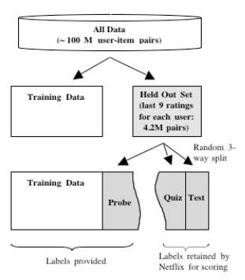

http://www2.research.att.com/~volinsky/papers/ASAStatComp.pdf

## Used by the professionals

[figure not shown]

http://www.kaggle.com/

## Avoid small sample sizes

- Suppose you are predicting a binary outcome
- Diseased/healthy
- Click on ad/not click on ad
- One classifier is flipping a coin
- Probability of perfect classification is approximately:
- $\left(\frac{1}{2}\right)^{sample \; size}$
- $n = 1$ flipping coin 50% chance of 100% accuracy
- $n = 2$ flipping coin 25% chance of 100% accuracy
- $n = 10$ flipping coin 0.10% chance of 100% accuracy

## Rules of thumb for prediction study design

- If you have a large sample size
- 60% training
- 20% test
- 20% validation
- If you have a medium sample size
- 60% training
- 40% testing
- If you have a small sample size
- Do cross validation
- Report caveat of small sample size

## Some principles to remember

- Set the test/validation set aside and *don’t look at it*
- In general *randomly* sample training and test
- Your data sets must reflect structure of the problem
- If predictions evolve with time split train/test in time chunks (called[backtesting](http://en.wikipedia.org/wiki/Backtesting) in finance)
- All subsets should reflect as much diversity as possible
- Random assignment does this
- You can also try to balance by features - but this is tricky